# PD5

Ivan Rukhavets

11/21/2018

## Opis zadania

Zadaniem w tej pracy domowej było przeprowadzenie eksperymentu polegającego na sprawdzeniu, czy błędy w odczytywaniu niektórych wykresów rzeczywiście występują. Jako rodzaj wykresu do testów wybrałem wykres słupkowy 3d w którym dodatkowo oś Y nie zaczynała się od 0.

## Opis eksperymentu

Na wykresie został umieszszone dane o wykrztałceniu kobiet i mężczyzn w polsce. Dane zostały pobrane z [eurostatu](https://stat.gov.pl/kobiety-i-mezczyzni-w-europie/bloc-2a.html?lang=pl). Ankietę wypełniło udział 16 osób o różnym backgroundzie technicznym.

Wykres testowany wyglądał tak:

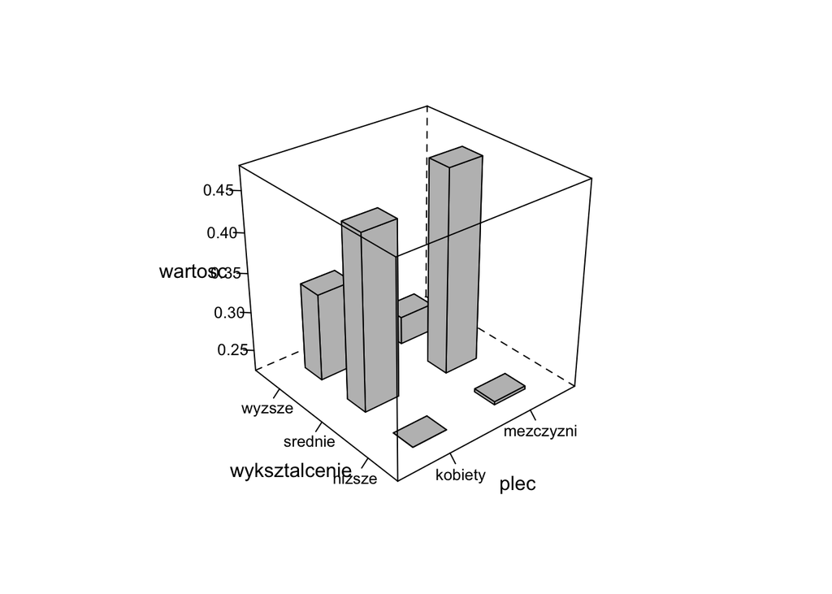

```r
cloud(wartosc~plec+wyksztalcenie, d, panel.3d.cloud=panel.3dbars, col.facet='grey',
      xbase=0.4, ybase=0.4, scales=list(arrows=FALSE, col=1),
      par.settings = list(axis.line = list(col = "transparent")))
```

Wykres “poprawny” był taki:

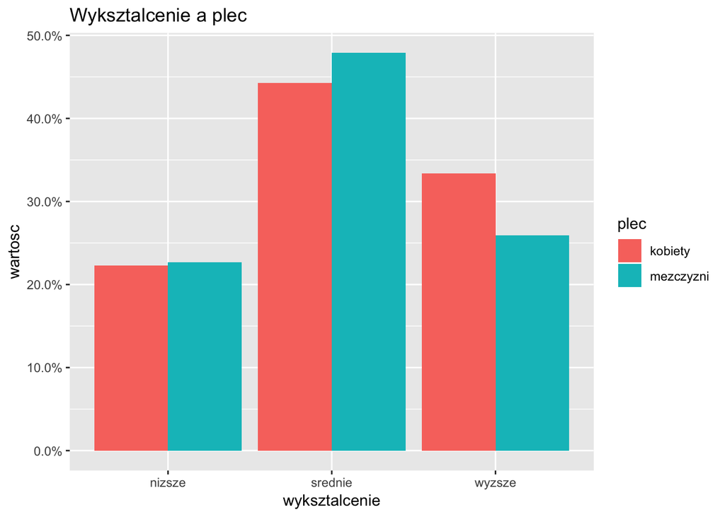

```r
ggplot(d, aes(x=wyksztalcenie, y=wartosc, fill=plec)) +
  scale_y_continuous(labels = scales::percent) +
  geom_bar(stat="identity", position=position_dodge()) +
  ggplot2::ggtitle('Wyksztalcenie a plec')
```

### Pytanie 1

*Z wykresu wynika że różnica między odsetkiem kobiet a mężczyzn z wykształceniem wyższym jest:*

- Trzykrotna
- Dwukrotna
- Poniżej 1.5-krotnej

Wyniki dla wykresy 3d były takie:

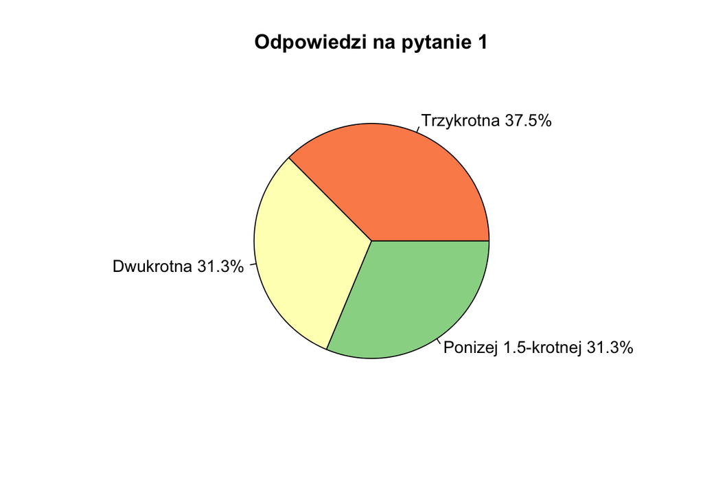

```r
percents = c(37.5, 31.3, 31.3)
labels = c('Trzykrotna', 'Dwukrotna', 'Ponizej 1.5-krotnej')
labels <- paste(labels, percents) # add percents to labels
labels <- paste(labels,"%",sep="")
pie(percents, labels, col = c('#fc8d59', '#ffffbf', '#99d594'), main='Odpowiedzi na pytanie 1')
```

Jak widać, odpowiedzi podzialiły się prawie idealnie porówno, co udowadnia, że informację tą nie da się odczytać z wykresu testowego. Dla odmiany, 100% ankietowanych wybrały poprawną odpowiedź w przypadku wykresu słupkowego.

### Pytanie 2

*Który wykres jest mniej czytelny?*

- 3d
- 2d

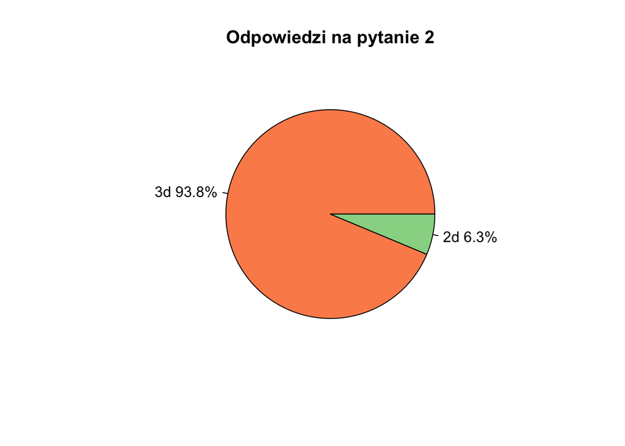

```r
percents = c(93.8, 6.3)
labels = c('3d', '2d')
labels <- paste(labels, percents) # add percents to labels
labels <- paste(labels,"%",sep="")
pie(percents, labels, col = c('#fc8d59', '#99d594'), main='Odpowiedzi na pytanie 2')
```

### Pytanie 3

*(Jeśli w poprzednim zadaniu wybrano 3d) Co bardziej utrudnia odczyt tego wykresu?*

- Niepotrzebna perspektywa
- Zakres osi Y (zaczyna się nie od 0)
- Wyżej wymienione wady są równie szkodliwe

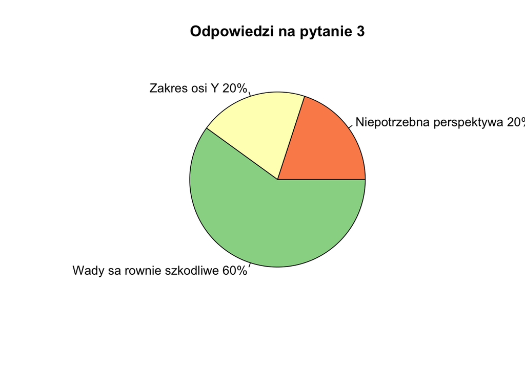

```r
percents = c(20, 20, 60)
labels = c('Niepotrzebna perspektywa', 'Zakres osi Y', 'Wady sa rownie szkodliwe')
labels <- paste(labels, percents) # add percents to labels
labels <- paste(labels,"%",sep="")
pie(percents, labels, col = c('#fc8d59', '#ffffbf', '#99d594'), main='Odpowiedzi na pytanie 3')
```

Z odpowiedzi na to pytanie wychodzi, że ankietowani głównie znajdują perspektywę i zakres osi Y równie szkodliwymi do poprawnego odczytu wykresu.

## Wnioski

Przeprowadzony eksperyment pokazał jak bardzo mylące mogą być wykresy słupkowe w perspektywie z osią Y zaczynającą się nie w punkcie 0. Poprawnie wykonany, zgrupowany wykres słupkowy był impreterowany jednoznacznie przez wszystkich, kiedy w przypadku wykresu 3d, odpowiedzi miały charakter prawie że losowy. Biorąc pod uwagę, że wykonanie zwykłego wykresu 2d jest prostrze, nie należy nigdy eksperymentować z perspektywą no i trzeba uważać z przedziałami na osiach.